# Navigating the Bayes Maze: The Psychologist’s Guide to Bayesian Statistics, a Hands-On Tutorial with R Code

Supplementary Materials

Udi Alter, Miranda A. Too, & Robert A. Cribbie

2024-13-10

# Getting Set Up

## Load required packages

```r
library(BayesFactor)
library(bayesplot)
library(bayestestR)
library(brms)
library(car)
library(GGally)
library(haven)
library(misty)
library(tidyverse)
```

# Research Example

Suppose a team of researchers is interested in understanding how age and education affect political knowledge. To answer this question, the research team surveys $N = 340$ adult respondents between the ages of 18 and 90 years residing in the United States. Participants were asked a series of survey questions about their knowledge of politics and the political process. Responses from the survey questions were aggregated into a composite score representing political knowledge.

## Import data

The data is openly available on Andrew Hayes’s website. You can download the entire zip file [here](https://afhayes.com/regression-analysis-and-linear-models.html#:~:text=miscellaneous%20additional%20files%3A-,Download,-New%20to%20SPSS). Once you unzip the file and click on the folder labeled “ralm”, look for the “politics.sav” file inside the POLITICS folder. Make sure that you save (or move) the “politics.sav” file to your working directory. Alternatively, you can include the directory path inside the quotation marks followed by a slash (/) inside the `read_sav()` function below.

```r
politics <-  haven::read_sav("politics.sav") %>%
  select(pknow, age, educ) # including only variables we will be working with
```

# Prelude

Before we embark on this analysis, we should identify what are the goals of this analysis. In this example, we intend to:

- Describe the association between education and political knowledge in terms of its magnitude and precision
- Explain (as opposed to predict; see [Yarkoni & Westfall, 2017](https://pubmed.ncbi.nlm.nih.gov/28841086/)) the nature of the relationship between education and political knowledge while partialling out the effects of age, and assessing the validity of the linear model with political knowledge regressed on both education and age.

We should also report on why we choose a Bayesian approach:

- We would like to incorporate prior knowledge about the relationship of interest as reported in previous studies
- Given the somewhat modest sample size, we would like to have computationally rigorous, more robust estimates and measures of uncertainty

# Descriptives and data visualizations

```r
descript(politics)
```

```
##  Descriptive Statistics
##
##   Variable   n nNA   pNA     M    SD   Min   Max  Skew  Kurt
##    pknow   340   0 0.00% 11.31  4.37  0.00 21.00 -0.09 -0.57
##    age     340   0 0.00% 44.93 14.59 18.00 90.00  0.48 -0.17
##    educ    340   0 0.00% 14.29  2.10  6.00 17.00 -0.58  0.21
```

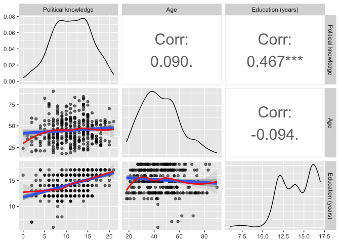

```r
# Function to return points and geom_smooth
# allow for the method to be changed
my_fn <- function(data, mapping, method1="lm", method2= "loess",...){
  p <- ggplot(data = data, mapping = mapping) +
    geom_point() +
    geom_smooth(method=method1, size=2)+
    geom_smooth(method=method2, span = 0.7, colour="red", alpha=0.2)
  p
}
# Figure S1 in Supplemental Materials
ggpairs(politics[,c(1,2,3)], aes(alpha = 0.5),
        columnLabels = c("Political knowledge","Age",
                         "Education (years)"),
       # diag=list(continuous=wrap("barDiag", binwidth=7)),
        lower = list(continuous = my_fn),
        upper = list(continuous = wrap('cor', size = 8)))
```

*Note*. The tiles cascading diagonally show the density plot of the univariate distributions of the individual variables. The tiles in the upper triangle show the linear correlation coefficients where *** indicates statistical significance (p < .001). The tiles in the lower triangle contain scatterplots representing the bivariate relationship between each pair of variables. The blue line reflects the fitted slope of the linear model whereas the red line represents a nonparametric smoothing using loess with a span of 0.7 to evaluate potential nonlinear trends.

# Model Selection

To help shed some light on how age and education explain political knowledge, we can use multiple linear regression with political knowledge as the outcome variable, whereas age and education are the regressors. Whether we use frequentist or Bayesian analyses, the linear model has the same form

$$y_i = b_0 + b_1 X_{1_i} + b_2 X_{2_i} +
\epsilon_i$$

where $y_i$ is the *i*th observed political knowledge value, $b_0$ is the population parameter representing the intercept of the regression plane, $b_1$ and $b_2$ are the population parameters representing the partial slopes (regression coefficients) of the first and second predictor variables, $X_{1_i}$ and $X_{2_i}$ are the $i$th ($i = 1, …,N$) observed values for the first and second predictor variables, and $\epsilon_i$ is the error term, $\epsilon_i = y_i - \hat{y}_i$, with $\hat{y}_i$ being the predicted value on the outcome variable for case $i$. For our research example, we can rewrite the equation above as

$$pknow_i = b_0 + b_{age}age_{i} +
b_{educ} educ_i$$

# Choosing and Justifying Priors

Suppose we have good reason to believe (e.g., perhaps from results of a meta-analysis) that the regression coefficient for the partial association between age and political knowledge is roughly 0.07 (i.e., for every additional year, we expect political knowledge score to increase by 0.07-points). But, we are only somewhat confident about this specific value; perhaps we would be more comfortable adding some uncertainty such that our prior for age is

$${b}_{age} \sim N(0.07, \
0.01),$$

which reads: the regression coefficient of age is normally distributed with a mean of 0.07 and variance of 0.01. Similarly, we can set the prior for education based on previous beliefs or evidence as

$${b}_{education} \sim N(1.05, \
0.09),$$

The two priors we set above are examples of informative priors because they are informed and justifiable by previous research findings.

Because we do not have the same privilege for the intercept and auxiliary parameters (i.e., the standard deviation of the model residuals), we will use weakly informative, more broad priors to allow a stronger “pull” from the data. These priors will be given by the software default.

# Using `brms`

To install and load the current official version of **brms**, we use the following commands:

```r
install.packages("brms", dependencies = T)
```

Next, we load the package so we can use it in this session.

```r
library(brms)
```

To set informative priors for the coefficients of age and education, you can use the `set_prior()` function:

```r
prior.age <- set_prior("normal(0.07, 0.1)", class = 'b', coef = "age")

prior.educ <- set_prior("normal(1.05, 0.3)", class = 'b', coef = "educ")
```

Note that the first argument in the function specifies the prior distribution family and its hyperparameters; that is, a normal (Gaussian) distribution with a mean of 0.07 and 1.05 and a standard deviation of 0.1 and 0.3 for age and education, respectively. The class argument specifies for which type of parameter we are setting the prior. In our case, we set it to `b`, the regression coefficient. If we wanted to specify the priors for the intercept and auxiliary parameters, we could set the class argument to `Intercept` and `sigma`, respectively. To view all the parameters we can specify for this model, we can use the `get_prior()` function with the formula and data arguments:

```r
get_prior(pknow ~ age + educ,  data = politics) # shows which parameters can be assigned a prior
```

```
##                  prior     class coef group resp dpar nlpar lb ub       source
##                 (flat)         b                                       default
##                 (flat)         b  age                             (vectorized)
##                 (flat)         b educ                             (vectorized)
##  student_t(3, 11, 4.4) Intercept                                       default
##   student_t(3, 0, 4.4)     sigma                             0         default
```

# Prior Predictive Checks

When doing Bayesian analysis, the accuracy of your results depends a lot on how good your prior is. It’s really important to check if the model you’re using actually produces data that makes sense. One way to do this is called prior predictive checking. Priors are built on what we already know and, as long as this knowledge is correctly translated into probabilities, they shouldn’t be wrong. Still, even with a solid method for creating priors, you need to really understand the specifics of these probabilities ([Daimon, 2008](https://doi.org/10.1016/j.cct.2008.05.005); [Moran et al., 2019](https://arxiv.org/abs/1908.00882); [van de Schoot et al., 2021](https://doi.org/10.1038/s43586-020-00001-2)). This is even more crucial for complex models with small sample sizes because less data means the priors have a bigger impact on the results ([Smid et al., 2019](https://doi.org/10.1080/10705511.2019.1577140)). Prior predictive checking helps you see how these priors might affect the observations, but it’s not necessarily about changing your priors, unless they clearly produce incorrect data ([van de Schoot et al., 2021](https://doi.org/10.1038/s43586-020-00001-2)).

The prior predictive distribution shows all possible samples that could happen if the model is accurate. Ideally, a “correct” prior will give a prior predictive distribution similar to the real data-generating process. Prior predictive checking involves comparing the observed data (or its statistics, *T*) with the prior predictive distribution (or its statistics) to see if they match up ([van de Schoot et al., 2021](https://doi.org/10.1038/s43586-020-00001-2)).

To evaluate the prior predictive check, we would need to rerun the model with the added argument `sample_prior = "only"`, as seen below

```r
# Prior predictive check with the argument sample_prior="only"
prior_pred_check <- brm(formula= pknow ~ age + educ, #the model
                 data=politics, # the data
                     prior = c(prior.age, prior.educ), #previously defined priors
                 family = gaussian(), #the likelihood function family
                 sample_prior = "only") # Simulating prior-based samples
```

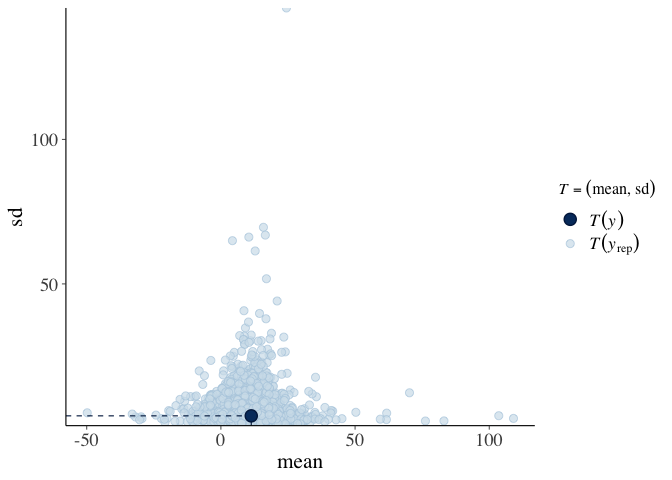

```r
# Generate prior predictive samples
prior_pred_samples <- posterior_predict(prior_pred_check,
                                        sample_prior = "only")
attributes(politics$pknow) <- NULL
# Plot the PPC
bayesplot::ppc_stat_2d(y = politics$pknow, yrep = prior_pred_samples) +
  scale_y_continuous(expand = c(0, 0)) +
  theme(axis.text = element_text(size = 14),
        axis.title = element_text(size = 16))
```

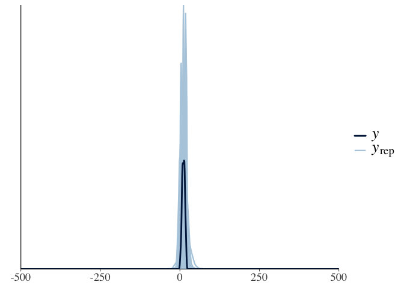

```r
# Generate prior predictive samples
prior_pred_samples <- posterior_predict(prior_pred_check,
                                        sample_prior = "only")

# Prior kernel density plot
bayesplot::ppc_dens_overlay(y = politics$pknow,
                                                 yrep = prior_pred_samples[1:40, ],
                                                 alpha = 1, size = 0.8) +
  xlim(-500, 500) +
  ylab("") +
  theme(axis.text = element_text(size = 14),
        axis.title = element_text(size = 16),
        legend.text = element_text(size = 20))
```

Above, are a few plots comparing the possible samples from the prior predictive distribution and the observed data. The priors cover the entire plausible parameter space with the observed data in the centre. The prior predictive checks for the priors we chose seem reasonable given the data. But, remember, you might want to repeat this process with different priors and reassess their appropriateness - this should be done as part of the sensitivity analysis, which is a crucial step in Bayesian analyses.

# Model Estimation and Posteriors Approximation

```r
bayes.reg <- brm(formula= pknow ~ age + educ, #the model
                 data=politics, # the data
                   prior = c(prior.age, prior.educ), #previously defined priors
                 family = gaussian(), #the likelihood function family

##### (optional) technical MCMC computation arguments below this line #####

                  iter = 6000, #number of iterations/samples in each chain
                warmup = 1000, #warm-up/burn-in
                thin = 5, # keeping every 5th sample in each chain
                chains = 4, #number of chains
                  cores = 7, #if using parallel processing
                seed = 311) #setting a seed number for reproducibility
```

Note the new arguments added such as the one specifying the prior/s, the distribution family of the likelihood function. There are also more technical specifications relating to the MCMC posterior approximation process such as the number of chains, the number of samples in each chain, the warm-up period, the number of cores, and the seed, in case we want to reproduce these exact results. To extract the results, we can use

```r
summary(bayes.reg) # results output
```

```
##  Family: gaussian
##   Links: mu = identity; sigma = identity
## Formula: pknow ~ age + educ
##    Data: politics (Number of observations: 340)
##   Draws: 4 chains, each with iter = 6000; warmup = 1000; thin = 5;
##          total post-warmup draws = 4000
##
## Regression Coefficients:
##           Estimate Est.Error l-95% CI u-95% CI Rhat Bulk_ESS Tail_ESS
## Intercept    -4.88      1.59    -7.98    -1.74 1.00     3635     3661
## age           0.04      0.01     0.01     0.07 1.00     3843     3777
## educ          1.00      0.10     0.82     1.19 1.00     3680     3925
##
## Further Distributional Parameters:
##       Estimate Est.Error l-95% CI u-95% CI Rhat Bulk_ESS Tail_ESS
## sigma     3.84      0.15     3.55     4.14 1.00     4094     3913
##
## Draws were sampled using sampling(NUTS). For each parameter, Bulk_ESS
## and Tail_ESS are effective sample size measures, and Rhat is the potential
## scale reduction factor on split chains (at convergence, Rhat = 1).
```

Or, to get only the posteriors’ summaries,

```r
posterior_summary(bayes.reg) # with posterior means
```

```
##                  Estimate  Est.Error          Q2.5         Q97.5
## b_Intercept   -4.88146904 1.58997356   -7.97569616   -1.74350944
## b_age          0.04091563 0.01392532    0.01358537    0.06863983
## b_educ         1.00462382 0.09718317    0.81526371    1.19185593
## sigma          3.84040799 0.15106157    3.54911438    4.14419696
## Intercept     11.31102706 0.20696830   10.89779284   11.70990256
## lprior        -3.17678734 0.10596971   -3.45249640   -3.04502642
## lp__        -941.53926031 1.43790954 -945.06336343 -939.76829313
```

To retrieve the credible intervals, use

```r
bayestestR::hdi(bayes.reg)
```

```
## Highest Density Interval
##
## Parameter   |        95% HDI
## ----------------------------
## (Intercept) | [-8.08, -1.87]
## age         | [ 0.02,  0.07]
## educ        | [ 0.81,  1.19]
```

```r
bayestestR::eti(bayes.reg)
```

```
## Equal-Tailed Interval
##
## Parameter   |        95% ETI | Effects |   Component
## ----------------------------------------------------
## b_Intercept | [-7.98, -1.74] |   fixed | conditional
## b_age       | [ 0.01,  0.07] |   fixed | conditional
## b_educ      | [ 0.82,  1.19] |   fixed | conditional
```

# MCMC Diagnostics

Before we celebrate our results, we should also make sure the MCMC did its job well. Diagnostics of MCMC play a crucial role in assessing the reliability, validity, and efficiency in approximating the posterior. There are multiple ways of assessing the MCMC, the most helpful of which is simply plotting the sample draws and examining the progression of the iteration process. Using trace plots, we can evaluate how well the sampling process has explored the parameter space and converged to the target estimates. There are multiple “red flags” we should look out for when examining the trace plots. For brevity, we do not review MCMC diagnostic issues in detail. Nonetheless, we briefly mention these issues and show how they might appear so that readers can easily identify a problem should one arise. To get the trace plots, we can use the following code:

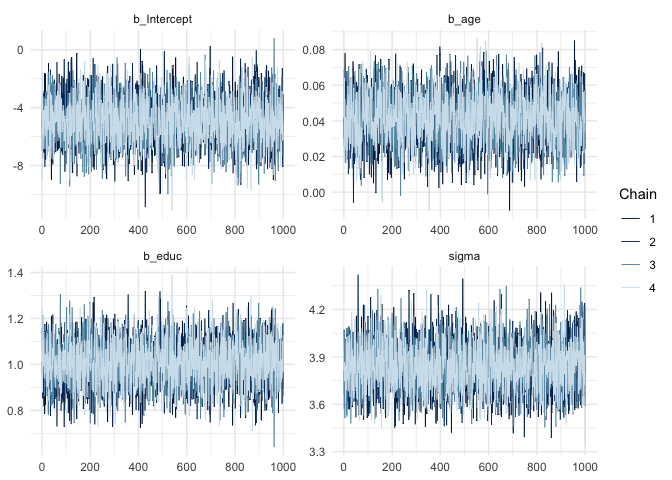

```r
bayesplot::mcmc_trace(bayes.reg, pars = vars(b_Intercept, b_age, b_educ, sigma))+theme_minimal()
```

We can “zoom-in” on a particular segment from sample such as iteration 200 to 250:

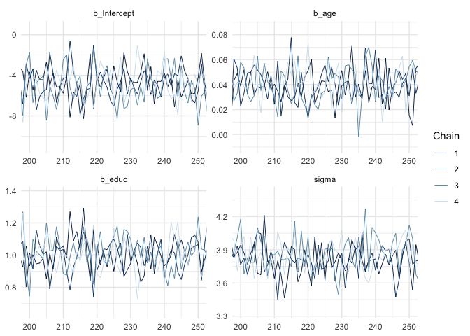

```r
bayesplot::mcmc_trace(bayes.reg, pars = vars(b_Intercept, b_age, b_educ, sigma), window=c(200,250))+theme_minimal()
```

```r
library(tidybayes)
```

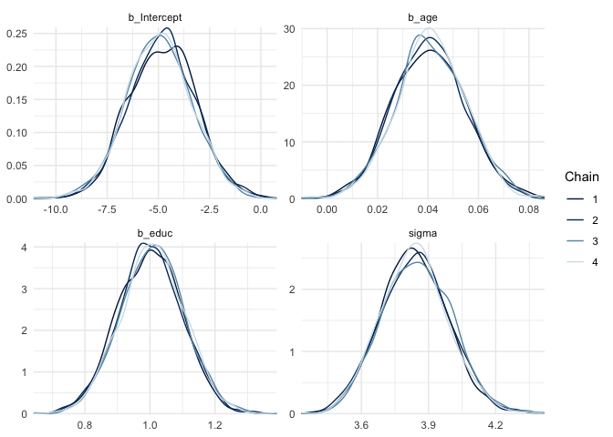

```r
draws <- as_draws_df(bayes.reg)

draws %>%
  mutate(chain = .chain) %>%
  mcmc_dens_overlay(pars = vars(b_Intercept, b_age, b_educ, sigma)) +
  theme_minimal()
```

We can observe close alignment between the 4 chains which increases our confidence in the reliability and accuracy of the MCMC process.

With a good mixture, we should be able to easily imagine a horizontal, flat line that crosses in the middle of the chains. Of course, no single diagnostic or trace plot is perfect, and we can never be completely certain that the quality of our MCMC sampling process is sufficient. All we can do is try to detect the presence of issues or red flags. Here are a few common issues which are also illustrated in plots below:

## Burn-in required

Burn-in refers to the initial period where the chain has not yet reached the stationary target. An example is presented at the top-left panel of Figure S5 showing a short iteration segment of adjustment before “climbing” to the estimated value and stabilizing.

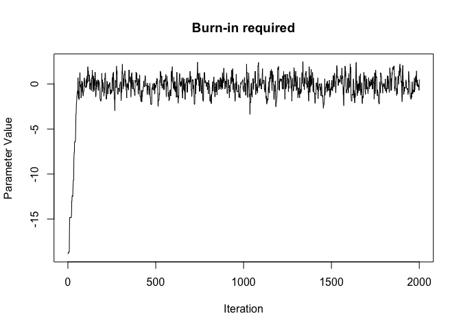

## Chains converging on different values

We use multiple chains to gain more confidence about the reliability of our posterior approximation. If one or more chains “disagree” (i.e., exhibit diverging patterns) as seen in the top-right corner of Figure S5, there may be potential problems in convergence and with our estimates.

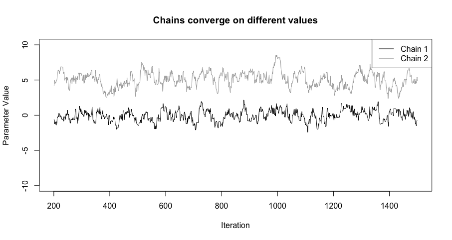

## Lack of convergence

When the chain does not stabilize and converge on a particular target, this might imply that the MCMC process did not explore the parameter space effectively and a reliable solution was not found. An example is visible at the bottom-left panel of Figure S5 where the chain reveals an erratic pattern or a systematic directionality without settling around a stable location.

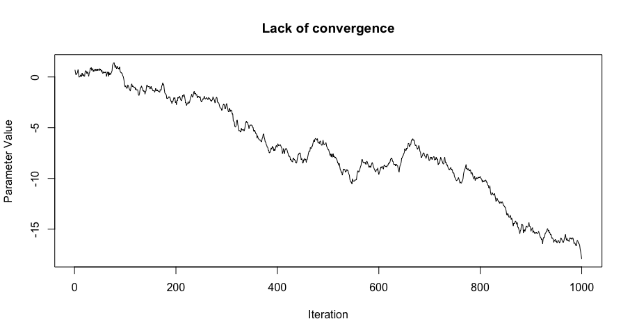

## Autocorrelation

Autocorrelation measures the association between a sample and its lagged versions in the chain. Although MCMC relies on some dependence between the samples, the issue with high autocorrelation is that it leads to slower exploration of the parameter space. This is noticeable in the bottom-right panel in Figure S5 where the waves in the trace plot have more “momentum” and they change direction less frequently.

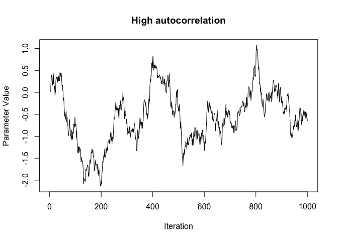

We can also plot autocorrelation plots using

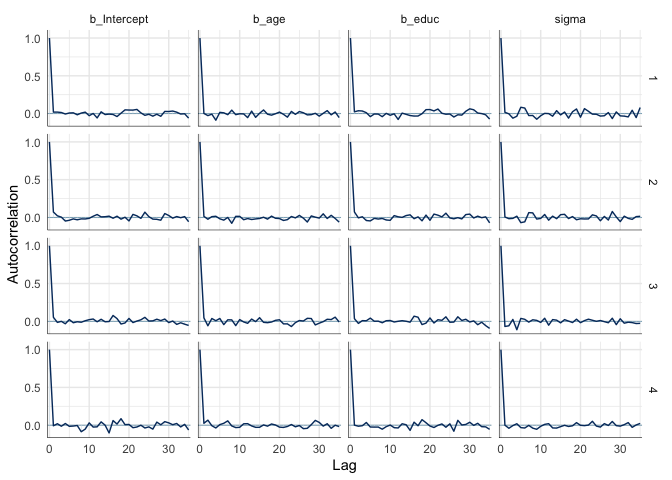

```r
draws %>%
  mutate(chain = .chain) %>%
  mcmc_acf(pars = vars(b_Intercept, b_age, b_educ, sigma), lags = 35) +
  theme_minimal()
```

```r
summary(bayes.reg)
```

```
##  Family: gaussian
##   Links: mu = identity; sigma = identity
## Formula: pknow ~ age + educ
##    Data: politics (Number of observations: 340)
##   Draws: 4 chains, each with iter = 6000; warmup = 1000; thin = 5;
##          total post-warmup draws = 4000
##
## Regression Coefficients:
##           Estimate Est.Error l-95% CI u-95% CI Rhat Bulk_ESS Tail_ESS
## Intercept    -4.88      1.59    -7.98    -1.74 1.00     3635     3661
## age           0.04      0.01     0.01     0.07 1.00     3843     3777
## educ          1.00      0.10     0.82     1.19 1.00     3680     3925
##
## Further Distributional Parameters:
##       Estimate Est.Error l-95% CI u-95% CI Rhat Bulk_ESS Tail_ESS
## sigma     3.84      0.15     3.55     4.14 1.00     4094     3913
##
## Draws were sampled using sampling(NUTS). For each parameter, Bulk_ESS
## and Tail_ESS are effective sample size measures, and Rhat is the potential
## scale reduction factor on split chains (at convergence, Rhat = 1).
```

Identifying these or related issues in the trace plots can help researchers detect potential problems with the MCMC sampling process and take corrective actions (e.g., removing the burn-in period, thinning, selecting a different starting value, etc.). Remember that it is always a good idea to use multiple diagnostics and conduct a thorough assessment of the MCMC results to increase the chances of a valid and reliable Bayesian inference.

## MCMC Statistics

We can also evaluate our MCMC process using MCMC statistics which are found in the result summary, under the `Regression Coefficients:` section. Specifically, we are looking for effective sample size (`bulk_ESS` and `tail_ESS`) and $\hat{R}$ (`Rhat`).

```r
summary(bayes.reg)
```

```
##  Family: gaussian
##   Links: mu = identity; sigma = identity
## Formula: pknow ~ age + educ
##    Data: politics (Number of observations: 340)
##   Draws: 4 chains, each with iter = 6000; warmup = 1000; thin = 5;
##          total post-warmup draws = 4000
##
## Regression Coefficients:
##           Estimate Est.Error l-95% CI u-95% CI Rhat Bulk_ESS Tail_ESS
## Intercept    -4.88      1.59    -7.98    -1.74 1.00     3635     3661
## age           0.04      0.01     0.01     0.07 1.00     3843     3777
## educ          1.00      0.10     0.82     1.19 1.00     3680     3925
##
## Further Distributional Parameters:
##       Estimate Est.Error l-95% CI u-95% CI Rhat Bulk_ESS Tail_ESS
## sigma     3.84      0.15     3.55     4.14 1.00     4094     3913
##
## Draws were sampled using sampling(NUTS). For each parameter, Bulk_ESS
## and Tail_ESS are effective sample size measures, and Rhat is the potential
## scale reduction factor on split chains (at convergence, Rhat = 1).
```

`Rhat`, `Bulk_ESS`, and `Tail_ESS` refer to $\hat{R}$, bulk, and tail effective sample size (ESS), which are statistics describing the MCMC process. For Bayesian inferences to be valid or hold any merit, the posterior approximation processes that give rise to these inferences must have been properly executed, and it’s our job to ensure it did. These statistics are only first-level checks.

Finally, ESS helps to assess the quality and efficiency of the sampling process. Because MCMC uses chained samples, we can expect these to be similar to, or dependent on one another to some degree (autocorrelation). But, we still want the samples to be somewhat independent because we need them to explore the parameter space thoroughly and efficiently. ESS is an estimate of the effective number of independent samples drawn from the posterior (either in the bulk of the distribution or the tails), where “the higher the ESS the better,” with a minimum ESS of 400, or 100 per chain ([Vehtari et al., 2021](https://projecteuclid.org/journals/bayesian-analysis/volume-16/issue-2/Rank-Normalization-Folding-and-Localization--An-Improved-R%CB%86-for/10.1214/20-BA1221.full), p. 672).

ESS required for an accurate and stable representation of the posterior distribution depends on the specific details you want to capture. For features influenced by dense regions in the parameter space, such as the median in unimodal distributions, a smaller ESS will likely be sufficient. However, for features influenced by sparse regions, like the 95% Highest Density Interval (HDI) limits, a larger ESS is necessary. This is because sparse regions are less frequently sampled, requiring longer chains to get a high-resolution view.

## What to Do When You Encounter Convergence Issues

Convergence issues in Bayesian analysis arise when the MCMC algorithm struggles to explore the parameter space effectively and find a solution, leading to unreliable posterior estimates. Like any other issue (not just in statistics), convergence issues can stem from a variety of causes. While it’s impossible to address all potential scenarios here, it’s important to start by diagnosing the problem. Using MCMC diagnostics, trace plots, and statistical checks can help identify the root cause for the convergence issues. With this understanding, here are some common steps that may help address these problems:

- **Increase the number of iterations and chains**: Sometimes, MCMC chains require more samples to adequately explore the parameter space. Increasing the number of iterations or the number of chains (e.g., from 4 to 6) can help the sampler converge on the posterior distribution. In the `brm()` function, you can increase the number of iteration by adjusting the value corresponding to the `iter =` argument. Similarly, the number of chains can be adjusted with the `chains =` argument.
- **Adjust the warm-up/burn-in period**: The warm-up or burn-in period allows the MCMC to stabilize before collecting samples. If chains fail to converge, increasing the burn-in period gives them more time to adjust to the target distribution. Users can use the `warmup =` argument in the `brm()` function.
- **Consider adjusting priors**: Strongly informative priors can sometimes pull the posterior too forcefully toward a specific region, leading to convergence issues. Increasing the uncertainty or spread of the informative prior, trying a weakly informative priors, or re-evaluating the appropriateness of the chosen priors can mitigate this issue.
- **Thin the chains**: Thinning involves keeping only every nth sample (e.g., every 5th) to reduce autocorrelation between samples, making the chains more independent and improving the chances of convergence success. Adjusting the thinning can be done using the `thin =` argument.
- **Consider the appropriateness of the model**: Sometimes convergence issues arise because the model itself may be too complex or poorly specified. It’s important to evaluate whether the model structure is appropriate for the data and the research question. Simplifying the model, removing unnecessary parameters, or ensuring the model aligns with the underlying data-generating process can often improve convergence. For instance, check whether all predictors are necessary or if there are redundant or collinear variables that could be removed.
- **Assess trace plots and R-hat values**: Examining trace plots for “mixing” of the chains and computing the R-hat diagnostic (which should be close to 1) will help detect whether the chains have properly converged. If not, consider rerunning the model with more robust computational settings (e.g., more iterations, fewer thinned samples).
- **Use alternative samplers**: Some issues are specific to the sampling algorithm used. For example, switching from the default NUTS (No-U-Turn Sampler) to another algorithm like Hamiltonian Monte Carlo (HMC) in `brms` can help address convergence issues.

Although this list of suggestions is helpful, it is not exhaustive and doesn’t go in-depth, given that this is an introductory tutorial. It’s important to approach each issue systematically, using diagnostics and trial-and-error, while considering the specific characteristics of your analysis. Additionally, any convergence problems and the steps taken to address them should be reported transparently in your results. This includes detailing any adjustments made and presenting sensitivity analyses to demonstrate the robustness of your findings under different model settings. Transparency in handling these issues is crucial for ensuring the credibility and reproducibility of the analysis.

# Model Fit

With OLS, we use multiple $R^2$ to assess the fit of the model. In Bayesian statistics, we have the **posterior predictive distribution (PPD)**. We use the PPD to evaluate how well the model fits the data. The idea behind assessing the adequacy of the model using the PPD is simple: Using the resulting posterior distribution(s) to inform our model about the parameters of interest, a new, hypothetical dataset is generated (predicted). If the model we estimated is adequate, then any fictitious data we generate using this model (i.e., model-implied predictions) should resemble our observed data (e.g., political knowledge scores). We can compare the distribution of the outcome variable generated from the model with the actual observed data to assess whether the model sufficiently captures the patterns and variability found in the observed data. Deviations between the observed and predicted data might suggest potential limitations in our model specification and can guide model refinement. Thus, the PPD indicates the likelihood of future observations (predictions) given the estimated parameters, the data, and our model.

A good approach to assess PPD is to plot the observed outcome distribution against the PPD which we can do using the code below:

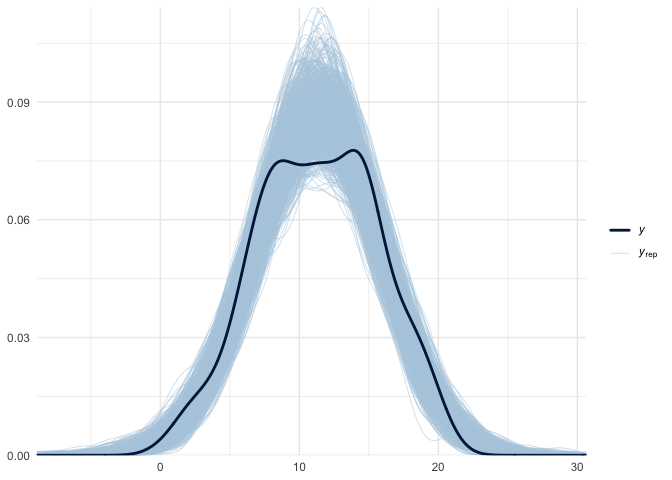

```r
pp_check(bayes.reg, ndraws = 1000)+theme_minimal()
```

The posterior predictive distribution is in light blue whereas the observed pknow scores are in dark blue. Because the two distributions seem well-aligned, we can conclude that the model fits sufficiently well.

There are a lot of other interesting ways to visualize model fit using PPD, for [example](https://mc-stan.org/rstanarm/reference/pp_check.stanreg.html#:~:text=The%20pp_check%20method%20for%20stanreg,than%20via%20the%20pp_check%20method).

# Interpreting `brm()` Output

Let’s look at the results, again:

```r
summary(bayes.reg) # results output
```

```
##  Family: gaussian
##   Links: mu = identity; sigma = identity
## Formula: pknow ~ age + educ
##    Data: politics (Number of observations: 340)
##   Draws: 4 chains, each with iter = 6000; warmup = 1000; thin = 5;
##          total post-warmup draws = 4000
##
## Regression Coefficients:
##           Estimate Est.Error l-95% CI u-95% CI Rhat Bulk_ESS Tail_ESS
## Intercept    -4.88      1.59    -7.98    -1.74 1.00     3635     3661
## age           0.04      0.01     0.01     0.07 1.00     3843     3777
## educ          1.00      0.10     0.82     1.19 1.00     3680     3925
##
## Further Distributional Parameters:
##       Estimate Est.Error l-95% CI u-95% CI Rhat Bulk_ESS Tail_ESS
## sigma     3.84      0.15     3.55     4.14 1.00     4094     3913
##
## Draws were sampled using sampling(NUTS). For each parameter, Bulk_ESS
## and Tail_ESS are effective sample size measures, and Rhat is the potential
## scale reduction factor on split chains (at convergence, Rhat = 1).
```

First, note that there are no significance testing results; there are no *t* or *p* values. Second, each row includes the summary statistics of the estimated posterior probability distribution for a particular model parameter. For example, the posterior distribution of $b_{educ}$ has a mean of 1.00-points per year on the political knowledge scale (shown under `Estimate`) and a standard deviation of 0.10-points (shown under `Est.Error`). Note that the **brms** default under `Estimate` is the posterior mean, but you can get the posterior median instead by adding the argument `robust=TRUE` inside the `summary()` function. For example:

```r
posterior_summary(bayes.reg, robust = TRUE) # # with median and the median absolute deviation (MAD)
```

```
##                 Estimate  Est.Error          Q2.5         Q97.5
## b_Intercept   -4.8802124 1.59642704   -7.97569616   -1.74350944
## b_age          0.0407869 0.01374194    0.01358537    0.06863983
## b_educ         1.0049992 0.09675354    0.81526371    1.19185593
## sigma          3.8399921 0.15258468    3.54911438    4.14419696
## Intercept     11.3125772 0.20528416   10.89779284   11.70990256
## lprior        -3.1534962 0.08144832   -3.45249640   -3.04502642
## lp__        -941.2079463 1.24621820 -945.06336343 -939.76829313
```

# Plotting the Posterior/s

The easiest way to visualize the posterior distributions and MCMC chains is with the `plot()` and `pairs()` functions.

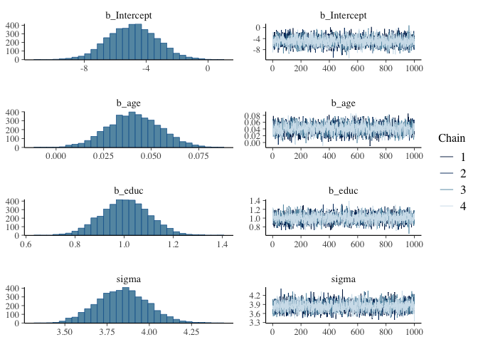

```r
plot(bayes.reg)
```

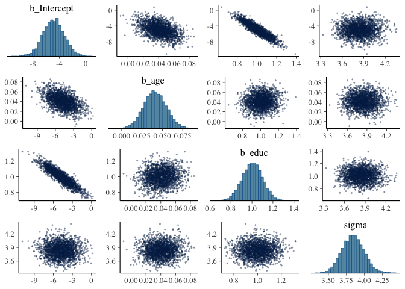

```r
pairs(bayes.reg,
      off_diag_args = list(size = 1/3, alpha = 1/3))
```

The next plot shows the posterior distribution of education, highlighting its mean and 95% credible interval.

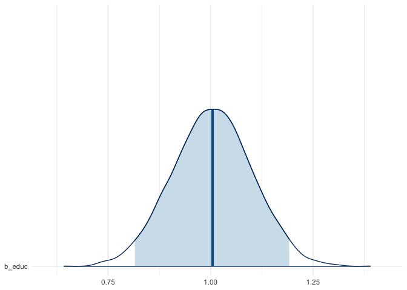

```r
library(bayesplot)
mcmc_areas(bayes.reg, pars=c("b_educ"), prob=.95)+
  theme_minimal()
```

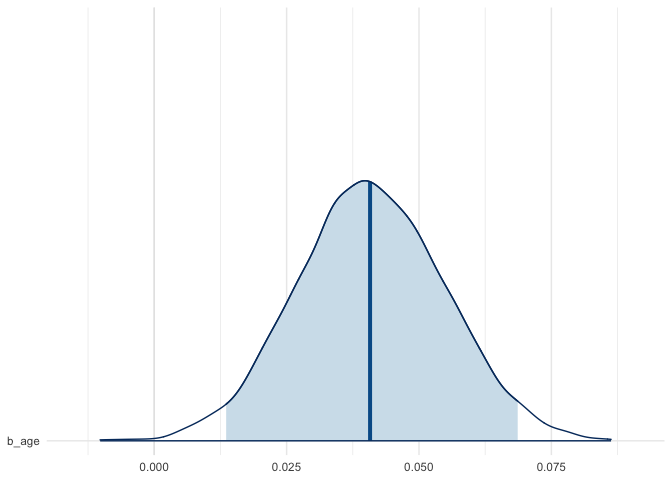

```r
mcmc_areas(bayes.reg, pars=c("b_age"), prob=.95)+
  theme_minimal()
```

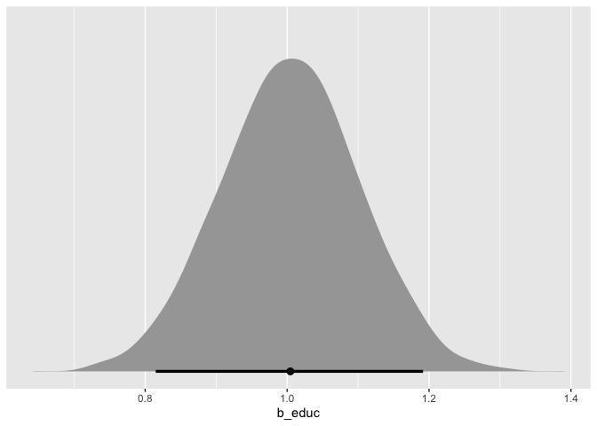

```r
library(tidybayes)

draws %>%
  ggplot(aes(x = b_educ, y = 0)) +
  stat_halfeye(point_interval = mean_hdi, .width = .95) +
  scale_y_continuous(NULL, breaks = NULL)
```

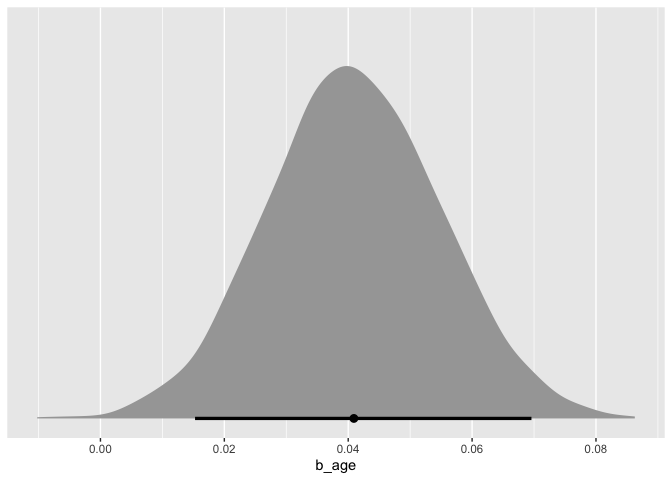

```r
draws %>%
  ggplot(aes(x = b_age, y = 0)) +
  stat_halfeye(point_interval = mean_hdi, .width = .95) +
  scale_y_continuous(NULL, breaks = NULL)
```

Another useful way of visualizing the posterior distribution is by plotting the estimated regression lines as illustrated below: We randomly sampled 1000 regression coefficients that correspond to education (of the same model we used above) from the approximated posterior distribution. These 1000 slopes are presented in light grey whereas their mean is in blue. Because we have 1000 regression lines, it looks like a grey band. But, these are just many light grey lines. The code to reproduce this plot is at the end of this document.

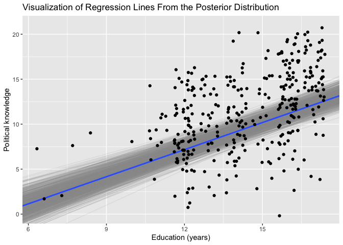

```r
fits <- draws %>%
  as_tibble() %>%
  rename(intercept = `b_Intercept`, educ = b_educ) %>%
  select(-sigma)

#head(fits)
# aesthetic controllers
n_draws <- 1000
alpha_level <- .15
color_draw <- "grey60"
color_mean <-  "#3366FF"
# make the plot
ggplot(politics) +
  # first - set up the chart axes from original data
  aes(x = educ, y = pknow ) +
  # restrict the y axis to focus on the differing slopes in the
  # center of the data
  coord_cartesian(ylim = c(0, 21)) +
  # Plot a random sample of rows from the simulation df
  # as gray semi-transparent lines
  geom_abline(
    aes(intercept = intercept, slope = educ),
    data = sample_n(fits, n_draws),
    color = color_draw,
    alpha = alpha_level
  ) +
  # Plot the mean values of our parameters in blue
  # this corresponds to the coefficients returned by our
  # model summary
  geom_abline(
    intercept = mean(fits$intercept),
    slope = mean(fits$educ),
    size = 1,
    color = color_mean
  ) +
  geom_jitter() +
  # set the axis labels and plot title
  labs(x = 'Education (years)',
    y = 'Political knowledge' ,
    title = 'Visualization of Regression Lines From the Posterior Distribution')
```

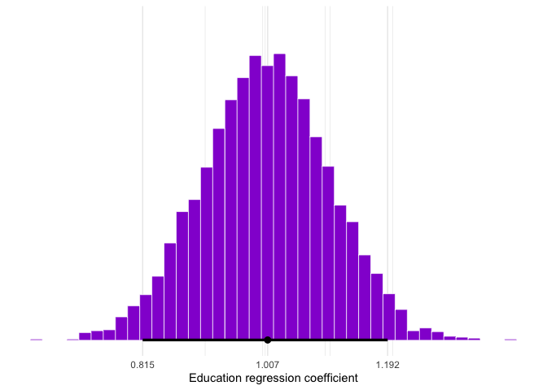

```r
my_breaks <-
  mode_hdi(draws$b_educ)[, 1:3] %>%
  pivot_longer(everything(), values_to = "breaks") %>%
  mutate(labels = breaks %>% round(digits = 3))

draws %>%
  ggplot(aes(x = b_educ, y = 0)) +
  stat_histinterval(point_interval = mode_hdi, .width = .95,
                    fill = "darkviolet", slab_color = "white",
                    breaks = 40, slab_size = .25, outline_bars = T) +
  scale_x_continuous(breaks = my_breaks$breaks,
                     labels = my_breaks$labels) +
  scale_y_continuous(NULL, breaks = NULL) +
  labs(x = "Education regression coefficient") +
  theme_minimal()
```

We can also visualize the posterior of education generated by each chain:

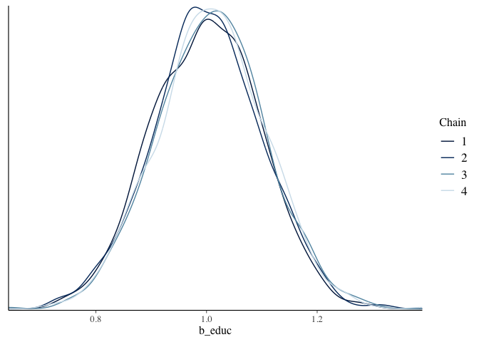

```r
draws %>%
  mutate(chain = .chain) %>%
  mcmc_dens_overlay(pars = vars(b_educ))
```

Here, we see that the four chains are quite consistent and are overlying closely. This is something we discussed in MCMC diagnostics, too.

# Prior Sensitivity Analyses

Sensitivity analysis is essential for comprehending Bayesian results in applied research. Without conducting a sensitivity analysis, it’s challenging to distinguish the prior’s impact from the data’s impact during the estimation process; a sensitivity analysis simply helps researchers to understand the relative influence of priors versus data ([Depaoli et al., 2020](https://www.frontiersin.org/journals/psychology/articles/10.3389/fpsyg.2020.608045/full)).

In sensitivity analyses, different priors are entertained and we can use Bayes factors to compare the same model using different priors so we can assess which priors are best supported by the data.

Recall the priors we set for our primary model, `bayes.reg`

```r
prior_summary(bayes.reg)
```

```
##                  prior     class coef group resp dpar nlpar lb ub  source
##                 (flat)         b                                  default
##      normal(0.07, 0.1)         b  age                                user
##      normal(1.05, 0.3)         b educ                                user
##  student_t(3, 11, 4.4) Intercept                                  default
##   student_t(3, 0, 4.4)     sigma                             0    default
```

Now, let’s try some other priors for education and see how the posterior distributions change.

```r
prior.educ2 <- set_prior("normal(0.75, sqrt(0.0625))", class = 'b', coef = "educ")
prior.educ3 <- set_prior("normal(0, 1)", class = 'b', coef = "educ")
prior.educ4 <- set_prior("normal(3, 1)", class = 'b', coef = "educ")
```

Now, let’s rerun the same model, using the different priors:

```r
bayes.reg2 <- brm(formula= pknow ~ age + educ, #the model
                 data=politics, # the data
                     prior = c(prior.age, prior.educ2), #previously defined priors
                 family = gaussian(), #the likelihood function family

##### (optional) technical MCMC computation arguments below this line #####

                    iter = 6000, #number of iterations/samples in each chain
                warmup = 1000, #warm-up/burn-in
                thin = 5, # keeping every 5th sample in each chain
                chains = 4, #number of chains
                    cores = 7, #If using parallel processing
                seed = 311) #setting a seed number for reproducibility


bayes.reg3 <- brm(formula= pknow ~ age + educ, #the model
                 data=politics, # the data
                     prior = c(prior.age, prior.educ3), #previously defined priors
                 family = gaussian(), #the likelihood function family

##### (optional) technical MCMC computation arguments below this line #####

                    iter = 6000, #number of iterations/samples in each chain
                warmup = 1000, #warm-up/burn-in
                thin = 5, # keeping every 5th sample in each chain
                chains = 4, #number of chains
                    cores = 7, #If using parallel processing
                seed = 311) #setting a seed number for reproducibility

bayes.reg4 <- brm(formula= pknow ~ age + educ, #the model
                 data=politics, # the data
                     prior = c(prior.age, prior.educ4), #previously defined priors
                 family = gaussian(), #the likelihood function family

##### (optional) technical MCMC computation arguments below this line #####

                    iter = 6000, #number of iterations/samples in each chain
                warmup = 1000, #warm-up/burn-in
                thin = 5, # keeping every 5th sample in each chain
                chains = 4, #number of chains
                    cores = 7, #If using parallel processing
                seed = 311) #setting a seed number for reproducibility
```

Next, we’re going to plot the different $b_{educ}$ posteriors corresponding to the different priors.

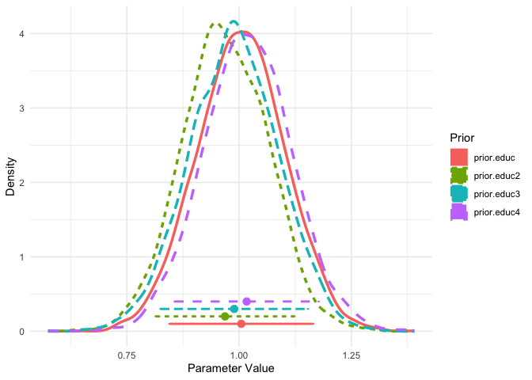

```r
# we first sample from the different posterior
original_posterior <- posterior_samples(bayes.reg, pars = "b_educ")
posterior_2 <- posterior_samples(bayes.reg2, pars = "b_educ")
posterior_3 <- posterior_samples(bayes.reg3, pars = "b_educ")
posterior_4 <- posterior_samples(bayes.reg4, pars = "b_educ")

# Then, combine them all to one dataframe for easier plotting
posteriors1234 <- bind_rows("prior.educ" = gather(original_posterior),
                            "prior.educ2" = gather(posterior_2),
                            "prior.educ3" = gather(posterior_3),
                            "prior.educ4" = gather(posterior_4),
                            .id = "Prior")
# changing the column names for convenience
colnames(posteriors1234) <- c("Prior" ,"Posterior"  , "value")

posterior_stats <- posteriors1234 %>%
  group_by(Prior) %>%
  summarize(median_value = median(value),
            lower_ci = quantile(value, 0.05),
            upper_ci = quantile(value, 0.95),
            mean_ci = mean(c(quantile(value, 0.05), quantile(value, 0.95))))

# Calculate density data for each group
density_data <- posteriors1234 %>%
  group_by(Prior) %>%
  do(data.frame(density(.$value)[c("x", "y")]))

# Extract the max density values
max_density_values <- density_data %>%
  group_by(Prior) %>%
  summarize(max_density = max(y))

# Combine stats and max density values
posterior_stats <- left_join(posterior_stats, max_density_values, by = "Prior")

# Define transparency levels
alpha_levels <- c("prior.educ" = 1, "prior.educ2" = 0.3, "prior.educ3" = 0.3, "prior.educ4" = 0.3)

# Define height for credible intervals
ci_height <- c(0.1, 0.2, 0.3, 0.4)  # Fixed height for credible interval lines

# Plotting
ggplot(data = posteriors1234,
       mapping = aes(x = value, colour = Prior, linetype = Prior)) +
  geom_density(size = 1.2) +
  theme_minimal() +
  geom_segment(data = posterior_stats,
               aes(x = lower_ci, xend = upper_ci, y = ci_height, yend = ci_height,
                   colour = Prior, linetype = Prior),
               size = 1) +
  geom_point(data = posterior_stats,
             aes(x = mean_ci, y = ci_height,
                 colour = Prior, fill = Prior),
             size = 3, shape = 21) +
  geom_segment(data = posterior_stats,
               aes(x = lower_ci, xend = lower_ci, y = ci_height - 0.01, yend = ci_height + 0.01,
                   colour = Prior, linetype = Prior),
               size = 1) +
  geom_segment(data = posterior_stats,
               aes(x = upper_ci, xend = upper_ci, y = ci_height - 0.01, yend = ci_height + 0.01,
                   colour = Prior, linetype = Prior),
               size = 1)+xlab("Parameter Value")+ylab("Density")
```

In the plot above, we see each of the posterior distributions for $b_{educ}$ which correspond to the different priors. Each posterior has a different line type and colour. We can also see the 90% credible interval associated with each posterior and its mean illustrated by the coloured circle in the middle of the interval.

Despite some subtle variations between the distributions, means, and credible intervals - the distributions and credible intervals overlap substantially - the different priors we set for $b_{educ}$ do not influence our posterior, and thus our results, to a meaningful degree. This gives us further support for the robustness of our inference and confidence in the prior we originally set for $b_{educ}$.

In this scenario we see very little change in the results when using different priors. However, the change in posteriors can often be substantial when using different priors, and it might feel intimidating at first to see that the sensitivity analysis shows priors strongly affecting the final model estimates. But this isn’t something to worry about too much. If the sensitivity analysis shows that even small changes in the prior settings significantly alter the final results, it’s an important discovery, too. This might mean that the theory behind setting the priors has a major influence on the model outcomes, and discovering this helps us understand how stable the model or theory is. On the other hand, if the model results stay pretty consistent despite changes in prior settings, it shows that the theory (or priors) has less impact on the findings. Either way, the results are noteworthy and should be thoroughly explained in the discussion. Understanding how priors influence the model will ultimately lead to more refined and informed theories in the field [Depaoli et al., 2020](https://www.frontiersin.org/journals/psychology/articles/10.3389/fpsyg.2020.608045/full). The bottom line is that the researcher needs to carefully explore and investigate any interesting changes in the posteriors following adjustments of priors and be honest when sharing their results ([Kruschke, 2021](https://www.nature.com/articles/s41562-021-01177-7)).

Note that for this demonstration, we only perform prior sensitivity analysis for a single parameter, $b_{educ}$. However, the prior sensitivity analysis should be done for all parameters.

# Hypothesis Testing

Examining the output from the results summary will reveal no *p* values or any indication of significance testing. Bayesian statistics does not use tests of significance in the traditional sense we know and love (to hate). Instead, the focus is on the magnitude, precision, and probability of the estimated effects. That said, we can still answer questions like “what is the probability that $b_{educ}=0$?” or, “what is the probability that $b_{educ}$ is greater than 0.8?” Answers to questions such as these are often what we wish the *p* value would tell us, but it doesn’t. To answer these questions, we can calculate the proportion of the posterior that satisfies the condition in question (e.g., $b_{educ}>0.8$). With **brms**, we can use the `hypothesis()` function:

```r
brms::hypothesis(bayes.reg, "educ > 0.8", alpha = .05)
```

```
## Hypothesis Tests for class b:
##         Hypothesis Estimate Est.Error CI.Lower CI.Upper Evid.Ratio Post.Prob
## 1 (educ)-(0.8) > 0      0.2       0.1     0.05     0.36      60.54      0.98
##   Star
## 1    *
## ---
## 'CI': 90%-CI for one-sided and 95%-CI for two-sided hypotheses.
## '*': For one-sided hypotheses, the posterior probability exceeds 95%;
## for two-sided hypotheses, the value tested against lies outside the 95%-CI.
## Posterior probabilities of point hypotheses assume equal prior probabilities.
```

In our example, `Evid.Ratio` is 60.54 which means that $b_{educ}>0.8$ is about 60 times more likely than $b_{educ}<0.8$. Note that for two-sided hypotheses (e.g., $b_{educ}=0$), the `Evid.Ratio` is a **Bayes factor**, which is the posterior density at the point of interest divided by the prior density.

## Bayes Factor

A Bayes Factor (BF) is a statistic used to compare two competing hypotheses or models. BF measures the strength of evidence in favour of one hypothesis over the other, given the observed data. It’s a ratio that quantifies how much more likely the observed data is under one model compared to another.

> “The factor by which the data shift one’s prior beliefs about the relative plausibility of two competing models is now widely known as the Bayes factor, and it is arguably the gold standard for Bayesian model comparison and hypothesis testing.”

Let’s break it down a bit further. We start with some terms and their definitions:

- Prior Odds: The ratio of the probabilities of the two models (e.g., Model 1 and Model 0; M1 and M0) before looking at the data (e.g., $\frac{P(M1)}{P(M0)}$)
- Posterior Odds: the ratio of the probabilities of the two models after considering the data (e.g., $\frac{P(M1|D)}{P(M0|D)}$)
- Bayes Factor: It is the ratio of Posterior Odds to Prior Odds, or the factor by which the Prior Odds are multiplied to obtain the Posterior Odds. It tells us how the data has changed our belief in the models

$$BF_{M1/M0}=\frac{P(M1|D)}{P(M0|D)}/\frac{P(M1)}{P(M0)}$$

After some rearrangements and simplifications using Bayes’s Theorem, we can rewrite this equation as

$$BF_{M1/M0}=\frac{P(D|M1)}{P(D|M0)}$$

Note the location “switch” between the model and D inside the brackets. Now, we’re dealing with P(D|M), which is the likelihood of the data, given the model (or hypothesis). Thus, what we see is that BF is the ratio of the likelihood of the data under M1 to the likelihood of the data under M0. Cool, right?

### Interpreting Bayes Factors

Generally, if the BF value is larger than 1, we say that the observed data are more likely under M1 than under M0. If BF is smaller than 1, it is the other way around; BF < 1 implies that the observed data are more likely under M0 than under M1. If BF is 1, the data are as likely under M1 as they are under M0.

### Bayes Factors in R

Here’s an example. Let’s evaluate our model, `bayes.reg`, against one of the alternative models generated as part of the sensitivity analysis discussed earlier. You’ll need the **BayesFactor** package

```r
library(BayesFactor)
bf <- bayes_factor(bayes.reg, bayes.reg2)
```

```r
bf
```

```
## Estimated Bayes factor in favor of bayes.reg over bayes.reg2: 1.29671
```

Here, we see that BF=1.297 which implies that, given the observed data, the `bayes.reg` model (with the prior for ${b}_{education} \sim N(1.05, \ 0.09)$) is 1.29 times more likely than the `bayes.reg2` model which has the ${b}_{education} \sim N(0.75, \ 0.0625)$ prior.

Right above, we actually compared the priors using BF, because the model was the same in terms of its variables and parameters. But, you can also compare models containing different variables or parameters, for example, perhaps you’d want to check whether a model *without* the predictor of age is more likely. You can define that model such that

```r
bayes.reg.educ.only <- brm(formula= pknow ~ educ, #the model
                 data=politics, # the data
                     prior = prior.educ, #previously defined priors
                 family = gaussian(), #the likelihood function family

##### (optional) technical MCMC computation arguments below this line #####

                    iter = 6000, #number of iterations/samples in each chain
                warmup = 1000, #warm-up/burn-in
                thin = 5, # keeping every 5th sample in each chain
                chains = 4, #number of chains
                    cores = 7, #If using parallel processing
                seed = 311) #setting a seed number for reproducibility


bfage <- bayes_factor(bayes.reg.educ.only, bayes.reg)
```

```r
bfage
```

```
## Estimated Bayes factor in favor of bayes.reg.educ.only over bayes.reg: 0.13675
```

BF=0.137 which implies that, given the observed data, the `bayes.reg.educ.only` model (having only the predictor of education, without age) is 0.14 times more likely than the `bayes.reg` model. Note, that BF is less than 1 which implies that `bayes.reg.educ.only` is **not** more likely. In fact, this hypothesized model without `age` is $(1-BF) \cdot 100\% = (1- 0.14) \cdot 100\% = 86\%$ **less** likely that our original model with includes both education and age as predictors. Or, alternatively, you can say that our original model, `bayes.reg` is $\frac{1}{BF}=\frac{1}{0.14}=7.3$ times more likely than the `bayes.reg.educ.only` model. This would be identical to changing the order of appearance of the models in the `bayes_factor()` function. Take a look:

```r
bayes_factor(bayes.reg, bayes.reg.educ.only)
```

```
## Iteration: 1
## Iteration: 2
## Iteration: 3
## Iteration: 4
## Iteration: 5
## Iteration: 1
## Iteration: 2
## Iteration: 3
## Iteration: 4
```

```
## Estimated Bayes factor in favor of bayes.reg over bayes.reg.educ.only: 7.29823
```

# List of Resources and Good Reads by Topic

Here, we provide just a few good reads and resources. But, there are plenty more out there, most of which will be made easier to read and much more accessible to novice Bayesians after reading the tutorial to which this document is accompanied.

## Bayesian Workflow

- [Bayesian Workflow (Gelman et al., 2020)](https://doi.org/10.48550/arXiv.2011.01808)
- [Bayesian Analysis Reporting Guidelines (Kruschke, 2021)](https://doi.org/10.1038/s41562-021-01177-7)
- [Bayesian statistics and modelling (van de Schoot et al., 2021)](https://www.nature.com/articles/s43586-020-00001-2)

## Textbooks

- [Applied Regression Analysis and Generalized Linear Models, Third Edition: Chapter 25 (draft) Bayesian Estimation of Regression Models (Fox, 2022)](https://socialsciences.mcmaster.ca/jfox/Books/Applied-Regression-3E/chap-25.pdf)
- [Bayesian Data Analysis (Gelman et al., 2013)](http://www.stat.columbia.edu/~gelman/book/)
- [Bayes Rules!: An Introduction to Applied Bayesian Modeling (Johnson & Dogucu, 2022)](https://www.bayesrulesbook.com/)
- [Doing Bayesian data analysis: A tutorial with R, JAGS, and Stan, second edition (Kruschke, 2015)](https://nyu-cdsc.github.io/learningr/assets/kruschke_bayesian_in_R.pdf)
- [Doing Bayesian Data Analysis in brms and the tidyverse, chapter 8 (Kurz, 2023)](https://bookdown.org/content/3686/jags-brms.html)
- [Statistical Rethinking: A Bayesian Course with Examples in R and STAN (McElreath, 2020)](https://www.taylorfrancis.com/books/mono/10.1201/9780429029608/statistical-rethinking-richard-mcelreath)

## Software

- [brms: An R Package for Bayesian Multilevel Models Using Stan (Bürkner, 2017)](https://doi.org/10.18637/jss.v080.i01)
- [Doing Bayesian data analysis: A tutorial with R, JAGS, and Stan, second edition (Kruschke, 2015)](https://nyu-cdsc.github.io/learningr/assets/kruschke_bayesian_in_R.pdf)
- [Doing Bayesian Data Analysis in brms and the tidyverse, chapter 8 (Kurz, 2023)](https://bookdown.org/content/3686/jags-brms.html)

## Understanding Priors and Their Impact (e.g., Sensitivity Analysis, Prior Predictive Check)

- [The Importance of Prior Sensitivity Analysis in Bayesian Statistics: Demonstrations Using an Interactive Shiny App (Depaoli et al., 2020)](https://www.frontiersin.org/journals/psychology/articles/10.3389/fpsyg.2020.608045/full)
- [Doing Bayesian data analysis: A tutorial with R, JAGS, and Stan, second edition (Kruschke, 2015)](https://nyu-cdsc.github.io/learningr/assets/kruschke_bayesian_in_R.pdf)
- [Influence of Priors: Popularity Data (Smeets & van de Schoot, 24 August, 2019)](https://www.rensvandeschoot.com/tutorials/brms-priors/)

## Bayesian Model Evaluation and Selection

- [Using leave-one-out (LOO) cross-validation and widely applicable information criterion (WAIC) (Vehtari et al., 2016)](http://www.stat.columbia.edu/~gelman/research/published/loo_stan.pdf)
- [Bayesian Model Averaging (Hinne et al., 2020)](https://journals.sagepub.com/doi/10.1177/2515245919898657)
- [Bayesian Model Averaging: A Tutoria (Hoeting et al., 1999)](https://www.stat.colostate.edu/~jah/papers/statsci.pdf)
- Objective Bayesian Methods for Model Selection: Introduction and Comparison (Berger & Pericchi, 2001)
- [Using Stacking to Average Bayesian Predictive Distributions (Yao et al., 2018)](http://www.stat.columbia.edu/~gelman/research/unpublished/combine_predictive.pdf)

## Reporting Guidelines and Examples

- [Improving transparency and replication in Bayesian statistics: The WAMBS-Checklist (Depaoli & van de Schoot, 2017)](https://doi.org/10.1037/met0000065)
- [The Importance of Prior Sensitivity Analysis in Bayesian Statistics: Demonstrations Using an Interactive Shiny App (Depaoli et al., 2020)](https://www.frontiersin.org/journals/psychology/articles/10.3389/fpsyg.2020.608045/full)
- [Bayesian Analysis Reporting Guidelines (Kruschke, 2021)](https://doi.org/10.1038/s41562-021-01177-7)